# Excel formatting

Brendan Clarke, NHS Education for Scotland, brendan.clarke2@nhs.scot

10/07/2024

## Welcome

- this session is for 🌶 Excel beginners
- we’ll get going properly at 15.05
- you’ll need Excel of some sort to follow along
- if you can’t access the chat, you might need to join our Teams channel: **tinyurl.com/kindnetwork**
- you can find session materials at **tinyurl.com/kindtrp**

## The KIND network

- a social learning space for staff working with **k**nowledge, **i**nformation, and **d**ata across health, social care, and housing in Scotland
- we offer social support, free training, mentoring, community events, …
- [Teams channel](https://teams.microsoft.com/l/team/19%3AQZ7-PbFVcziG2piHLt1_ifey3I2cwFL0yBuTSS8vVao1%40thread.tacv2/conversations?groupId=106d08f3-9026-40e2-b3c7-87cd87304d58&tenantId=10efe0bd-a030-4bca-809c-b5e6745e499a) / [mailing list](https://forms.office.com/pages/responsepage.aspx?id=veDvEDCgykuAnLXmdF5JmpopIZB9ynRJnrPUHVFccipURjM2NkZJUkhGOFlQRjQxRFhVUTgwT0UwVyQlQCN0PWcu)

## Excel training sessions

| Session | Date | Area | Level |
| --- | --- | --- | --- |
| Lambda formulas in Excel | 13:00-13:30 Mon 15th July 2024 | Excel | 🌶🌶 : **intermediate-level** |
| Lookups in Excel | 13:00-14:30 Thu 1st August 2024 | Excel | 🌶🌶 : **intermediate-level** |
| Relative, absolute, mixed, structured, and R1C1 references in Excel | 15:00-16:00 Thu 8th August 2024 | Excel | 🌶🌶 : **intermediate-level** |

## Where does this fit in?

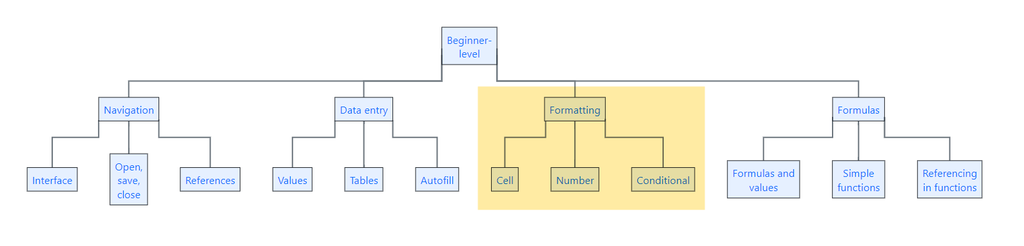

KIND Excel beginner skill tree

- for this session, you’ll need to be familiar with the Excel basics (getting around in Excel, opening/saving/closing files)
- you’ll also need to be familiar with A1 referencing, values, and tables
- we’re going to avoid talking about formulas as much as possible today

## Session outline

(thanks Deborah Calvin, Brian Orpin, Michael Roarty, Kenneth Mack, Catherine McGrenera, June Livey, Catriona Scott)

- accessibility
- formatting cells
- formatting values (aka **number formatting**)
- formatting vs other things
- shortcuts and tips
- an introduction to conditional formatting

## Accessibility

- many of us will have legal duties to make parts of our services accessible
  - e.g. [The Public Sector Bodies (Websites and Mobile Applications) Accessibility Regulations 2018](https://www.legislation.gov.uk/uksi/2018/852/contents/made)
- there are [useful standards for making sense of accessibility](https://www.w3.org/TR/WCAG21/)

## Excel is a mixed bag for accessibility

- it is easy to make non-accessible documents in Excel
  - merged and split cells
  - inconsistent use of tables
  - poor column headings, sheet names, etc
  - unlabelled charts
  - low-contrast themes
  - meaning conveyed by colour and fonts
- there is a [built-in accessibility checker in some versions of Excel](https://support.microsoft.com/en-gb/office/accessibility-best-practices-with-excel-spreadsheets-6cc05fc5-1314-48b5-8eb3-683e49b3e593), which you might find useful

## Formatting cells

- please create a new Excel workbook
- you can format each cell individually via the right click menu and `Format cells` (or by the `Ctrl` + `1` shortcut)

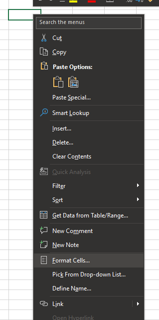

## Format cells dialogue

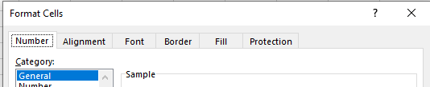

Format cells dialogue

- you can fill cells with custom fonts, alignments, colours, patterns, and gradients (via `Fill Effects...`)
- you can add borders to individual cells

## Formatting many cells

- this is fine for a few cells, but gets boring (and inconsistent) if you have lots of styling to do
- you can select several cells, and access the `Format cells dialogue` to style them together
- or you can select a cell with a theme you want to copy, and use the `Format Painter` tool to spread that format about the place

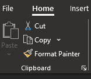

## Theming

- you can also **theme** your whole workbook

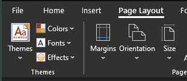

- take care, though, as many of these themes are not accessible and often produce hard-to-read results
- and lots of ugly clunky stuff to find (e.g. default font changes)
- on balance, better to avoid themes unless you’re certain they’ll be of benefit for you

## Help! I hate my formatting!

- `Clear` > `Clear Formats` (or `Alt`, `H`, `E`, `F`)

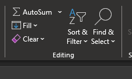

- note this doesn’t clear out all the formatting from themes - especially odd fonts etc
- also worth having the `Paste as Values` trick in your back pocket for when things go horribly wrong

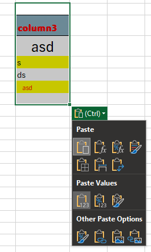

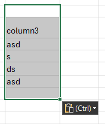

## Number formatting

- number formatting is taking a value, and changing its meaning with formatting
- number formatting is how dates work (or fail to work) in Excel
- dates are v. important, so we’ll concentrate on them in this part of the session
- you’ll also encounter number formatting when working with…
  - money
  - percentages
  - decimal places
  - …

## Date formatting

- we’ll take a number, and apply special formatting to it to make it look like a date
  - so `45483` will become `10/07/2024`
- Excel dates are stored as the number of days since Jan 1st 1900
- you can prove this to yourself by typing `1` into a cell, then formatting it as a date using the number formatting menu:

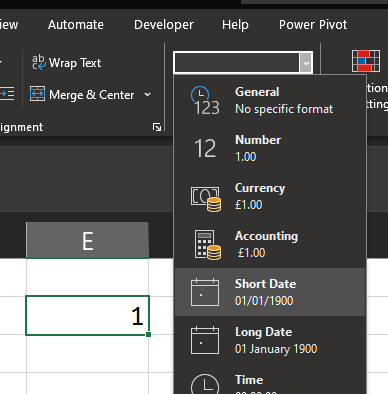

- you can also format as a date via the Format Cells dialogue (`Ctrl` + `1`)

## Don’t try and cheat with dates!

- date formatting is one of the commonest pain points in Excel
- dates are extremely complicated, and we often want to calculate with them
- the advice is simple: dates should always be stored as these numbers, and then formatted to look like dates
  - don’t try to cheat by writing dates as text
  - use formatting to produce your preferred date format in the Format Cells tools instead

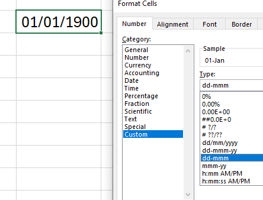

## Formatting vs other things

(or, keep your sheets clean)

- it’s common to see Excel sheets that contain lots of extraneous bits
  - headers, copyright info, explanations…
- ideally, all this extra stuff should be kept well away from your data, as it makes it harder to process that data safely
- …and you should definitely be using tables to help with this

## Conditional formatting

- this can get complicated, and we’ll revisit more fancy conditional formatting in the intermediate training sessions
- the big idea is that conditional formatting alters the format as values change

## Progress bars

- Put a few random numbers in a column
- Select them, and go to the Conditional Formatting menu
- Select Data Bars

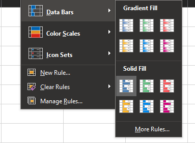

## Duplicate values

- Now clear that conditional formatting

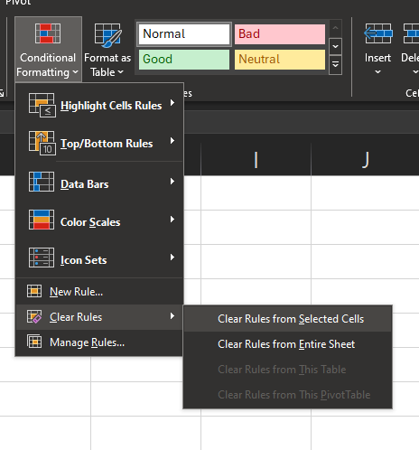

- Add a duplicate value to your numbers

## Duplicate values

- Highlight duplicate values

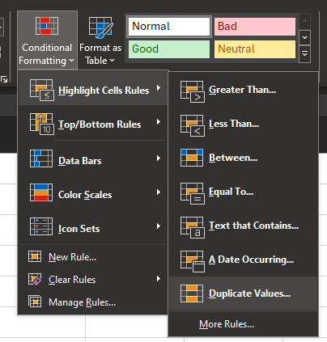

## Red-Amber-Green reporting

- RAG reporting with icon sets

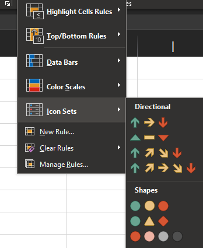

## Key shortcuts

- `Ctrl` + `1` for the Format Cells dialogue
- `Alt`, `H`, `E`, `F` to clear formats
- `Ctrl` + `v`, `Ctrl`, `v` to paste values only

## Formatting tips

- Accessibility is much more important than beauty
- Use number formatting for dates, currency, percentages
- Consider using validation to make sure that cells only contain what you expect them to contain
- Consider locking cells to protect formatting when that formatting is really important
- Use conditional formatting sparingly

## Feedback and resources

- please can I ask for some feedback - less than 1 minute, completely anonymous, helps people like you find the right training for them

| Session | Date | Area | Level |
| --- | --- | --- | --- |
| Lambda formulas in Excel | 13:00-13:30 Mon 15th July 2024 | Excel | 🌶🌶 : **intermediate-level** |
| Lookups in Excel | 13:00-14:30 Thu 1st August 2024 | Excel | 🌶🌶 : **intermediate-level** |
| Relative, absolute, mixed, structured, and R1C1 references in Excel | 15:00-16:00 Thu 8th August 2024 | Excel | 🌶🌶 : **intermediate-level** |